# OTX2 case study — Fig 3a

UCSC-browser snapshot of OTX2 CUT&RUN at the ZNF-cluster region (chr3:137.7-143.3 Mb) in 4C embryos (rep1, rep2), OTX2-KD 4C, 8C, 4C ATAC and primed hESC OTX2 ChIP (Tsankov et al.).

Paper: Wang, Q. *et al.* Maternal factor *OTX2* regulates human embryonic genome activation and early development. *Nature Genetics* **57**, 2772–2784 (2025). 10.1038/s41588-025-02350-8

> **Upstream / preprocessing.** FASTQ → BAM → bigwig, MACS2 peak calling, Xia 2019 / Zou 2022 / Gifford 2013 downloads, and the one-off xlsx → TSV extractions are all documented in `preprocess.ipynb`. This notebook starts from the cached inputs under `/scratch/users/steorra/data/otx2/`.

### Data availability

Primary data from the paper (Wang et al. 2025):

- **Raw sequencing**: GSA-Human `HRA006621` (controlled-access, not used here).
- **Processed bigwigs / peaks / counts**: OMIX `OMIX006476` ([link](https://ngdc.cncb.ac.cn/omix/view/OMIX006476)). Contains OTX2 CUT&RUN bigwigs (4C / 8C / KD / hESC), ATAC-seq bigwigs, and peak BEDs.
- **Supplementary tables S1-S7**: downloaded from the Nature article HTML (stage-activated gene lists, DEG tables, 4C OTX2 CUT&RUN peaks).

External data:

- **RNA / Ribo at pre-implantation stages** (Zou et al. 2022 *Science*): GEO `GSE197265` — processed bigwigs `GSE197265_h_{GV,MII,1C,2C,4C,8C,ICM}_rep12_merge_RNA_10bp_rpkm.bw`.
- **8C H3K4me3 / H3K27ac** (Xia et al. 2019 *Science*, paper ref 82): GEO `GSE124718` — `GSM3543863/4_hs_8cell_3PN_H3K4me3_rep{1,2}.bedGraph.gz` and `GSM3820010/11_hs_8cell_3PN_H3K27ac_rep{1,2}.bedGraph.gz` (we use 3PN because H3K27ac is only available in 3PN embryos).

Local layout used throughout these notebooks:

```
/scratch/users/steorra/data/otx2/
  OMIX006476/                 # paper's processed files
  GSE197265/                  # Zou 2022 RNA/Ribo bigwigs
  GSE124718/                  # Xia 2019 H3K4me3/H3K27ac (converted to bigwig)
  supp/supp_tables.xlsx       # paper's Supplementary Tables S1-S7
/scratch/users/steorra/data/hg19/
  hg19.fa, hg19.fa.fai, hg19.chrom.sizes
  gencode.v41lift37.annotation.gtf.gz
```

### Setup

```python
import os, pathlib, warnings
os.environ['PATH'] = '/scratch/users/steorra/env/omicdev/bin:' + os.environ.get('PATH', '')
warnings.filterwarnings('ignore', category=UserWarning)

import numpy as np
import pandas as pd
import matplotlib.pyplot as plt
import pyBigWig

# Paper / external data roots
DATA         = pathlib.Path('/scratch/users/steorra/data/otx2')
OMIX         = DATA / 'OMIX006476'        # paper processed
ZOU          = DATA / 'GSE197265'         # Zou 2022 RNA/Ribo
XIA          = DATA / 'GSE124718'         # Xia 2019 8C histone
SUPP_TABLES  = DATA / 'supp/supp_tables.xlsx'

HG19         = pathlib.Path('/scratch/users/steorra/data/hg19')
GENCODE_GTF  = HG19 / 'gencode.v41lift37.annotation.gtf.gz'
HG19_FA      = HG19 / 'hg19.fa'
HG19_SIZES   = HG19 / 'hg19.chrom.sizes'

import epione as epi
epi.pl.plot_set()
print('epione', epi.__version__ if hasattr(epi,'__version__') else 'dev')
```

[output not shown]

[output not shown]

[output not shown]

### Build the bigwig track dictionary and render Fig 3a

```
└─ Load bigWig files
  ├─ Loading OTX2 4C rep1...
  ├─ Loading OTX2 4C rep2...
  ├─ Loading OTX2 KD 4C...
  ├─ Loading OTX2 8C...
  ├─ Loading 4C ATAC...
  └─ Loading ESC OTX2...
└─ Load GTF file
  ├─ Reading GTF...
  └─ Reading GTF file from /scratch/users/steorra/data/hg19/gencode.v41lift37.annotation.gtf.gz...
```

```
  └─ GTF file read successfully
```

```
  └─ GTF loaded
```

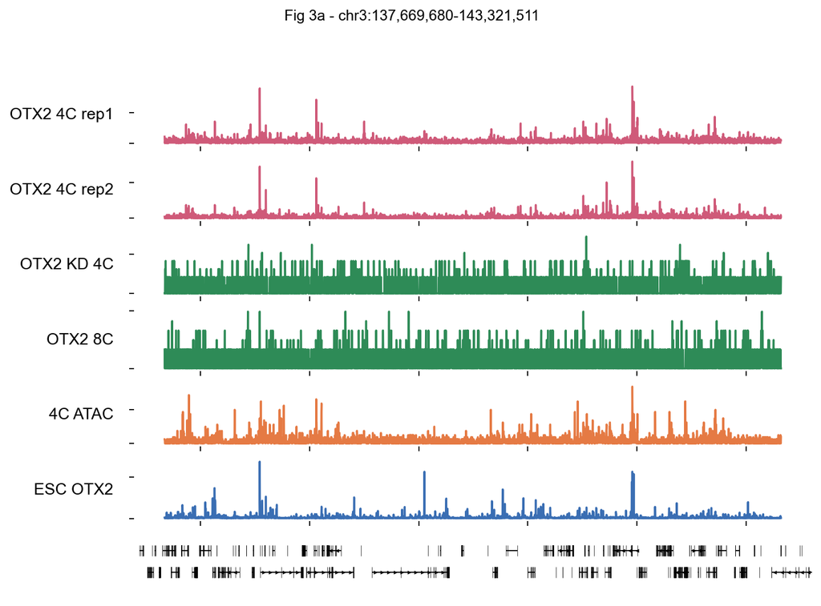

```python
bw_dict = {
    'OTX2 4C rep1': str(OMIX / 'h_OTX2_day2_CUTRUN_rep1_pmu_100bp_rpkm_bamCoverage.bw'),
    'OTX2 4C rep2': str(OMIX / 'h_OTX2_day2_CUTRUN_rep2_pmu_100bp_rpkm_bamCoverage.bw'),
    'OTX2 KD 4C':   str(OMIX / 'h_OTX2_day2_CUTRUN_OTX2_KD_pmu_100bp_rpkm_bamCoverage.bw'),
    'OTX2 8C':      str(OMIX / 'h_OTX2_day3_CUTRUN_pmu_100bp_rpkm_bamCoverage.bw'),
    '4C ATAC':      str(OMIX / 'h_OTX2_ctrl_day2_ATAC_reads_count_rep1.bw'),
    'ESC OTX2':     str(OMIX / 'H9_OTX2_ChIP_21Mcells_100bp_rpkm_bamCoverage.bw'),
}
fig3a_obj = epi.bulk.bigwig(bw_dict); fig3a_obj.read()
fig3a_obj.load_gtf(str(GENCODE_GTF))

chrom, cs, ce = 'chr3', 137_669_680, 143_321_511
fig3a_obj.gtf = fig3a_obj.gtf[fig3a_obj.gtf['seqname'] == chrom].reset_index(drop=True)

color_dict = {'OTX2 4C rep1': '#CF5A79', 'OTX2 4C rep2': '#CF5A79',
              'OTX2 KD 4C':   '#2E8B57', 'OTX2 8C':      '#2E8B57',
              '4C ATAC':      '#E57A44', 'ESC OTX2':     '#3A6EB3'}

fig, axes = fig3a_obj.plot_track(
    chrom, cs, ce,
    nbins=3500, value_type='max',
    figwidth=9, figheight=6,
    color_dict=color_dict,
    prefered_name='gene_name',
)
fig.suptitle(f'Fig 3a - {chrom}:{cs:,}-{ce:,}', fontsize=11, y=1.02)
plt.show()
```

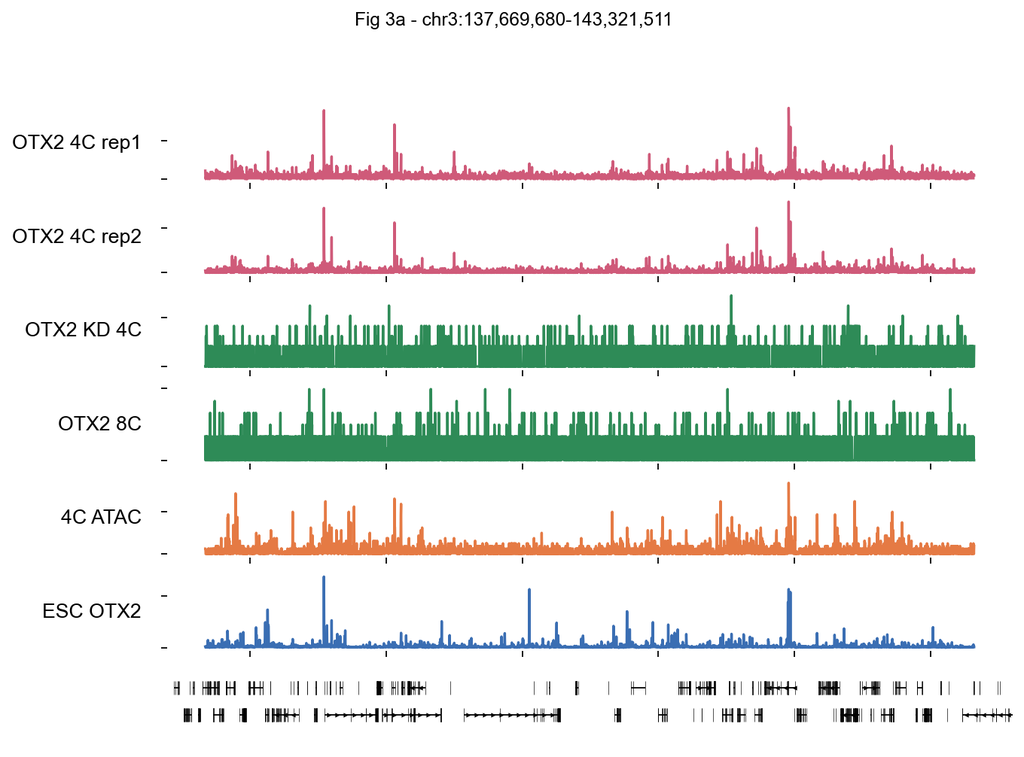

```python
fig, axes = fig3a_obj.plot_track(
    chrom, cs, ce,
    nbins=3500, value_type='max',
    figwidth=9, figheight=6,
    color_dict=color_dict,
    prefered_name='gene_name',
)
fig.suptitle(f'Fig 3a - {chrom}:{cs:,}-{ce:,}', fontsize=11, y=1.02)
plt.show()
```